# Bayesian parameter estimation

## So what is your belief

In lecture one we I tossed ten times. with a coin that was supposedly healed after hamering it straight.

I arbitrarily assumed my $H_A: \theta=.25$.

Considering all possible values of $\theta$

$[0,1] \Rightarrow \{\theta\in\Bbb R:0\le \theta\le 1\}$

## Draw your belief

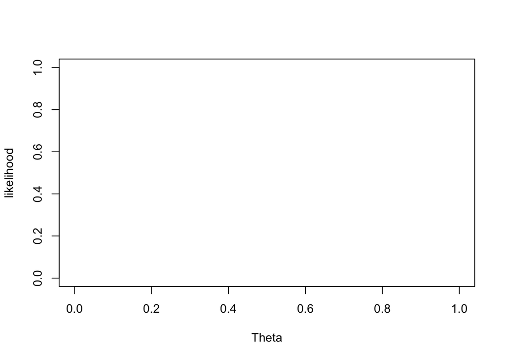

## Prior distribution

You have assigned a prior probability distribution to the parameter $\theta$.

> This is your prior

Now we normally do not draw our priors, but we could.

## Priors

We can choose a flat prior, or a beta distributed prior with different parameter values $a$ and $b$.

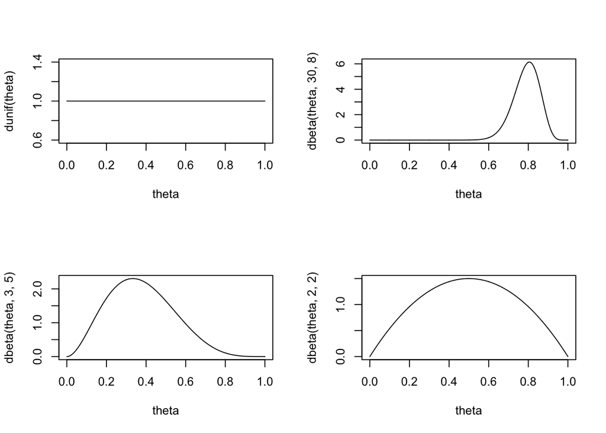

```r
theta = seq(0,1, .001)
layout(matrix(1:4,2,2))
plot(theta, dunif(theta), type="l")
plot(theta, dbeta(theta, 3, 5), type="l")
plot(theta, dbeta(theta, 30, 8), type="l")
plot(theta, dbeta(theta, 2, 2), type="l")
```

## Theta all mighty

The true value of $theta$ for our binomial distribution.

$$\Huge \theta = .68$$

The data driver!

## My ten tosses

My ten tosses landed heads 2 times.

$$\begin{aligned}
k &= 2 \\
n &= 10
\end{aligned}$$

```r
k = 2
n = 10
```

## Likelihood

How likely is the data assuming the data represents the parameter value:

$$\theta = \frac{2}{10} = 0.2$$

```r
theta.given.data = k/n
```

## Likelihood function

How likely is 2 out of 10 for all possible $\theta$ values?

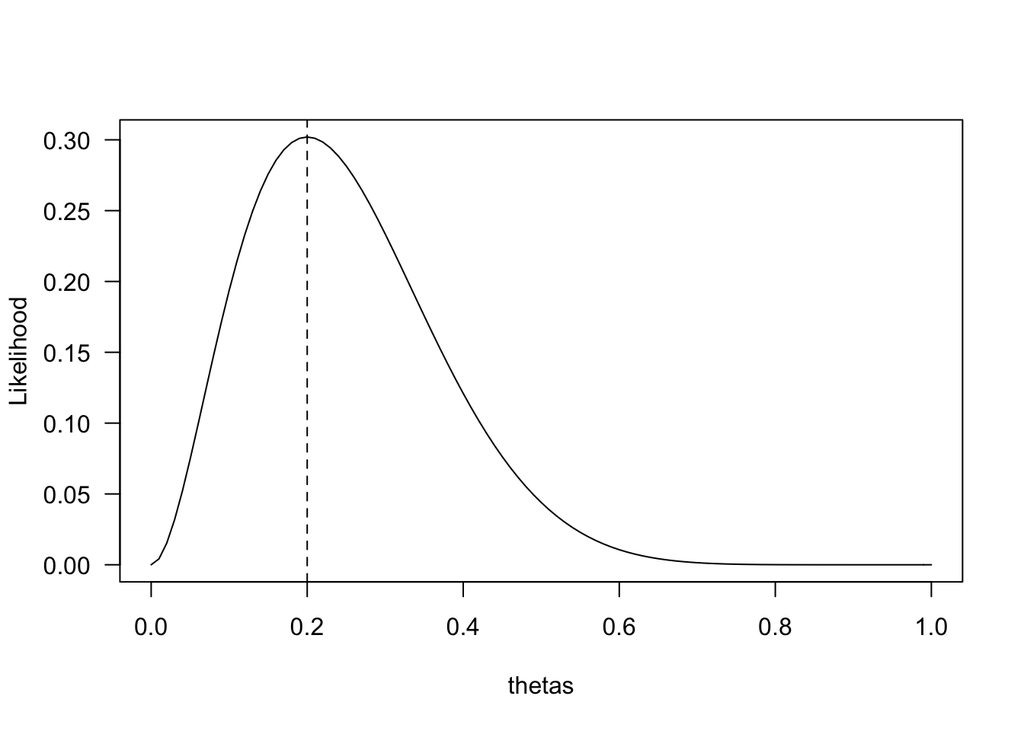

```r
thetas = seq(0, 1, .01)

likelihood =  dbinom(k, n, thetas)

plot(thetas, dbinom(k, n, thetas), type='l', ylab = "Likelihood", las = 1)
abline(v=theta.given.data, lty='dashed')
```

## Prior

What is our expectation of what $theta$ could really be?

It could be anything. We therefore could assign all passible values of $theta$ equally likely.

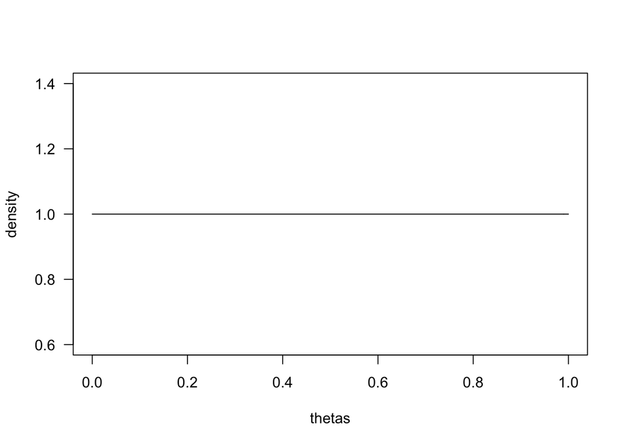

```r
prior = dbeta(thetas, 1,1)

plot(thetas,prior, type='l', ylab = "density", las = 1)
```

## Posterior

Now we can update our belief about the posible values of theta based on the data (the likelihood function) we found. For this we use Bayes rule.

$$\begin{aligned}
{Posterior} &\propto {Likelihood} \times {Prior} \\
P(\theta | D) &\propto P(D|\theta) \times P(\theta)
\end{aligned}$$

# Bayesian hypothesis testing